# EDA - Zdrowie psychiczne Studentów (University Students’ Mental Health)

# Opis zmiennych dotyczących zdrowia psychicznego studentów

#### 1. Timestamp (Znacznik czasu)

- Typ: Tekstowy (chr)
- Opis: Data wypełnienia ankiety przez studenta
- Przykład wartości: 13/7/2020

#### 2. Gender (Płeć)

- Typ: Tekstowy (chr)
- Opis: Płeć uczestnika ankiety
- Możliwe wartości:
  - Female - Kobieta
  - Male - Mężczyzna
  - Inne (jeśli występują, np. preferencje neutralne)

#### 3. Age (Wiek)

- Typ: Liczbowy (num)
- Opis: Wiek studenta w momencie wypełnienia ankiety
- Przykład wartości: 18, 24

#### 4. Course (Kierunek studiów)

- Typ: Tekstowy (chr)
- Opis: Kierunek studiów deklarowany przez studenta
- Przykład wartości: Engineering, Biotechnology

#### 5. YearOfStudy (Rok studiów)

- Typ: Tekstowy (chr)
- Opis: Aktualny rok studiów studenta
- Przykład wartości: Year 3, year 4

#### 6. CGPA (Średnia ocen)

- Typ: Liczbowy (num)
- Opis: Średnia ocen studenta (Cumulative Grade Point Average)
- Przykład wartości: 3.68, 4.00

#### 7. Depression (Depresja)

- Typ: Liczbowy (num)
- Opis: Wskaźnik wskazujący, czy student doświadcza symptomów depresji
- Możliwe wartości:
  - 0 - Brak objawów
  - 1 - Występują objawy

#### 8. Anxiety (Lęk)

- Typ: Liczbowy (num)
- Opis: Wskaźnik wskazujący, czy student doświadcza symptomów lęku
- Możliwe wartości:
  - 0 - Brak objawów
  - 1 - Występują objawy

#### 9. PanicAttack (Ataki paniki)

- Typ: Liczbowy (num)
- Opis: Wskaźnik wskazujący, czy student doświadczał ataków paniki
- Możliwe wartości:
  - 0 - Brak ataków
  - 1 - Występują ataki

#### 10. SpecialistTreatment (Leczenie specjalistyczne)

- Typ: Liczbowy (num)
- Opis: Informacja o tym, czy student korzysta z leczenia specjalistycznego w zakresie zdrowia psychicznego
- Możliwe wartości:
  - 0 - Nie korzysta
  - 1 - Korzysta

#### 11. SymptomFrequency_Last7Days (Częstotliwość objawów w ostatnich 7 dniach)

- Typ: Liczbowy (num)
- Opis: Liczba dni w ciągu ostatniego tygodnia, w których student doświadczał objawów problemów zdrowia psychicznego
- Przykład wartości: 5

#### 12. HasMentalHealthSupport (Wsparcie psychologiczne)

- Typ: Liczbowy (num)
- Opis: Czy student ma dostęp do wsparcia psychologicznego
- Możliwe wartości:
  - 0 - Brak wsparcia
  - 1 - Ma wsparcie

#### 13. SleepQuality (Jakość snu)

- Typ: Liczbowy (num)
- Opis: Ocena jakości snu studenta w skali od 1 do 5

#### 14. StudyStressLevel (Poziom stresu związanego ze studiami)

- Typ: Liczbowy (num)
- Opis: Ocena poziomu stresu związanego ze studiami w skali od 1 do 5

#### 15. StudyHoursPerWeek (Liczba godzin nauki tygodniowo)

- Typ: Liczbowy (num)
- Opis: Liczba godzin, które student przeznacza na naukę w tygodniu
- Przykład wartości: 15

#### 16. AcademicEngagement (Zaangażowanie w studia)

- Typ: Liczbowy (num)
- Opis: Ocena zaangażowania studenta w zajęcia akademickie w skali od 1 do 5

# Pytania badawcze i analiza danych

## 1. Które z objawów, takich jak depresja, lęk lub ataki paniki wystepują najczęściej?

Na początku przygotuje dane i przekonwertuje je do odpowiedniego typu:

```r
mentalhealth_data <- mentalhealth_data %>%
  mutate(
    Depression = as.numeric(as.character(Depression)),
    Anxiety = as.numeric(as.character(Anxiety)),
    PanicAttack = as.numeric(as.character(PanicAttack))
  )
```

```r
najczestsze_problemy <- mentalhealth_data %>%
  select(Depresja = Depression, Lek = Anxiety, AtakiPaniki = PanicAttack) %>%
  pivot_longer(
    cols = everything(),
    names_to = "Problem",
    values_to = "Występowanie"
  ) %>%
  filter(Występowanie == 1) %>%
  group_by(Problem) %>%
  summarize(LiczbaZgłoszeń = n(), .groups = "drop")

wykres_najczestsze_problemy <- ggplot(najczestsze_problemy, aes(x = Problem, y = LiczbaZgłoszeń, fill = Problem)) +
  geom_bar(stat = "identity", width = 0.7) +
  labs(
    title = "Najczęściej występujące problemy zdrowia psychicznego wśród studentów",
    x = "Rodzaj problemu",
    y = "Liczba zgłoszeń",
    fill = "Rodzaj problemu"
  ) +
  theme_minimal() +
  theme(
    plot.title = element_text(size = 14, face = "bold"),
    axis.title = element_text(size = 12),
    legend.position = "none",
    axis.text.x = element_text(angle = 45, hjust = 1)
  )
```

Wyświetlam wyniki:

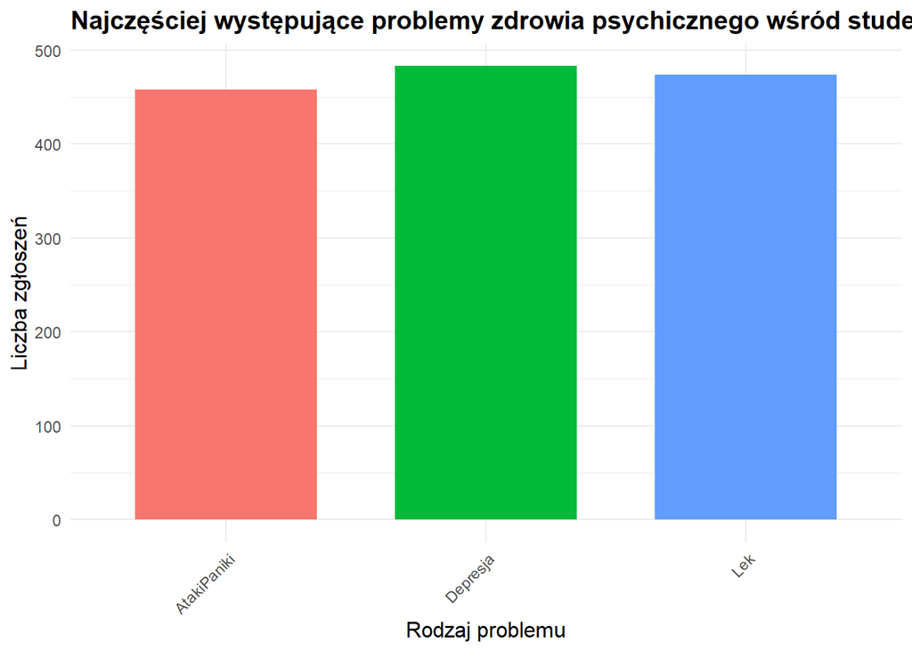

```r
wykres_najczestsze_problemy
```

#### Wyniki:

Z powyższego wykresu możemy zobaczyć, że ilość zgloszeń ataków paniki, depresji i lęku jest dość wyrównana, lecz najwięcej zgłoszeń dotyczy depresji.